# LAB2 MACHINE LEARNING

KIESGEN DE RICHTER Stanislas, PRECIGOUT Gabriel

We will work on bike rental dataset to predict the bike rental hourly and daily demand according to multiple parameters

# 1: Data preprocessing

First we import libraries and import our data as a single dataframe as it is a 5 sheet excel documetn at the beginning.

```python
#Import and Hyper parameters
import pandas as pd
import numpy as np
import matplotlib.pyplot as plt
import seaborn as sn
from sklearn.model_selection import train_test_split
from sklearn.metrics import r2_score
from sklearn.linear_model import LinearRegression
from sklearn.metrics import mean_absolute_error
from sklearn.metrics import mean_squared_error
import math
pd.options.mode.chained_assignment = None  # default='warn'
alpha = 0.03
iter_ = 10000
delta = 0.0000001
```

```python
df = pd.read_csv ("data/Bike_Rental_UCI_dataset.csv")
dfuntouched = df
print (df)
```

```
       season  yr  mnth  hr  holiday  workingday  weathersit  temp   hum  \
0           1   0     1   0        0           0           1  0.24  0.81
1           1   0     1   1        0           0           1  0.22  0.80
2           1   0     1   2        0           0           1  0.22  0.80
3           1   0     1   3        0           0           1  0.24  0.75
4           1   0     1   4        0           0           1  0.24  0.75
...       ...  ..   ...  ..      ...         ...         ...   ...   ...
17374       1   1    12  19        0           1           2  0.26  0.60
17375       1   1    12  20        0           1           2  0.26  0.60
17376       1   1    12  21        0           1           1  0.26  0.60
17377       1   1    12  22        0           1           1  0.26  0.56
17378       1   1    12  23        0           1           1  0.26  0.65

       windspeed dayOfWeek  days  demand
0         0.0000       Sat     0      16
1         0.0000       Sat     0      40
2         0.0000       Sat     0      32
3         0.0000       Sat     0      13
4         0.0000       Sat     0       1
...          ...       ...   ...     ...
17374     0.1642       Mon   723     119
17375     0.1642       Mon   723      89
17376     0.1642       Mon   724      90
17377     0.1343       Mon   724      61
17378     0.1343       Mon   724      49

[17379 rows x 13 columns]
```

## 1.1 Explaination of all the features:

- **season**: this feature can have 4 different values and describe the season when the data was gathered:
  - 1: winter season
  - 2: spring season
  - 3: summer season
  - 4: fall season
- **yr**: this feature can have 2 different values 1 or 0, if its 0 it corresponds to the year 2011 otherwise it corresponds to 2012.
- **mnth**: this feature's values goes from 1 to 12 with each number being associated to its month *i.e. January = 1*.
- **hr**: this feature's values goes from 0 to 23 with each number being associated to its hour *i.e. 2 corresponds to 2AM*.
- **holiday**: this feature states if there was an holiday or not for the data, 0 meaning no holiday and 1 correspond to a holiday.
- **workingday**: this feature tells us if it was a working day or not for the data, 0 meaning it was neither a working day or holiday and 1 meaning its a working day without being a holiday.
- **weathersit**: this feature can have 4 different values and describe the type of weather when the data was gathered:
  - 1: Clear, Few clouds, Partly cloudy, Partly cloudy.
  - 2: Mist + Cloudy, Mist + Broken clouds, Mist + Few clouds, Mist.
  - 3: Light Snow, Light Rain + Thunderstorm + Scattered clouds, Light Rain + Scattered clouds.
  - 4: Heavy Rain + Ice Pallets + Thunderstorm + Mist, Snow + Fog.
- **temp**: Normalized temperature in Celsius. The values are derived via (t-t_min)/(t_max-t_min), t_min=-8, t_max=+39 (only in hourly scale).
- **hum**: Normalized humidity. The values are divided to 100 (max).
- **windspeed**: Normalized wind speed. The values are divided to 67 (max).
- **dayOfWeek**: name of the day when the data was gathered.
- **days**: cumulative feature inscreasing over time and representing the number total of days passed when the data was gathered.
- **demand**: number of bikes rented when the data was gathered (this include the bikes rented by casual and registered customers).

## 1.2 Correlation matrix without dummies

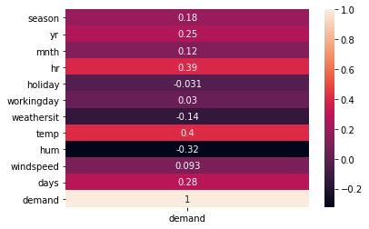

```python
corrMatrix = df.corr()
corrMatrixdemand= corrMatrix[["demand"]]
sn.heatmap(corrMatrixdemand, annot=True)
plt.show()
```